# Get model predictions and plot them with ggplot2

Stefano Coretta

2022-09-04

While `plot_smooths()` offers a streamlined way of plotting predicted smooths from a GAM model (see `vignette("plot-smooths", package = "tidymv")`), it is too constrained for other more complex cases.

The most general solution is to get the predicted values of the outcome variable according to all the combinations of terms in the model and use this dataframe for plotting. This method grants the user maximum control over what can be plotted and how to transform the data (if necessary).

I will illustrate how to use the function `predict_gam()` to create a prediction dataframe and how this dataframe can be used for plotting different cases.

Let’s load the necessary packages.

```r
library(ggplot2)
theme_set(theme_bw())
library(dplyr)
library(mgcv)
library(tidymv)
```

## Smooths

First of all let’s generate some simulated data and create a GAM model with a factor `by` variable.

```r
library(mgcv)
set.seed(10)
data <- gamSim(4, 400)
```

```
#> Factor `by' variable example
```

```r
model <- gam(
  y ~
    fac +
    s(x2, by = fac),
  data = data
)

summary(model)
```

```
#>
#> Family: gaussian
#> Link function: identity
#>
#> Formula:
#> y ~ fac + s(x2, by = fac)
#>
#> Parametric coefficients:
#>             Estimate Std. Error t value Pr(>|t|)
#> (Intercept)   1.2219     0.1634   7.478 5.17e-13 ***
#> fac2         -1.7395     0.2376  -7.322 1.44e-12 ***
#> fac3          2.2505     0.2301   9.779  < 2e-16 ***
#> ---
#> Signif. codes:  0 '***' 0.001 '**' 0.01 '*' 0.05 '.' 0.1 ' ' 1
#>
#> Approximate significance of smooth terms:
#>              edf Ref.df      F p-value
#> s(x2):fac1 2.750  3.426  3.749 0.00763 **
#> s(x2):fac2 2.738  3.403 41.046 < 2e-16 ***
#> s(x2):fac3 7.140  8.195 35.734 < 2e-16 ***
#> ---
#> Signif. codes:  0 '***' 0.001 '**' 0.01 '*' 0.05 '.' 0.1 ' ' 1
#>
#> R-sq.(adj) =  0.643   Deviance explained = 65.6%
#> GCV = 3.6879  Scale est. = 3.5438    n = 400
```

```r
model_p <- predict_gam(model)
model_p
```

```
#> # A tibble: 150 × 4
#>    fac        x2    fit se.fit
#>    <fct>   <dbl>  <dbl>  <dbl>
#>  1 1     0.00134  1.02   0.546
#>  2 2     0.00134 -2.80   0.508
#>  3 3     0.00134 -1.70   0.801
#>  4 1     0.0217   1.04   0.487
#>  5 2     0.0217  -2.72   0.454
#>  6 3     0.0217  -0.616  0.612
#>  7 1     0.0421   1.06   0.435
#>  8 2     0.0421  -2.65   0.407
#>  9 3     0.0421   0.477  0.484
#> 10 1     0.0625   1.08   0.390
#> # … with 140 more rows
```

Now plotting can be done with `ggplot2`. The convenience function `geom_smooth_ci()` can be used to plot the predicted smooths with confidence intervals.

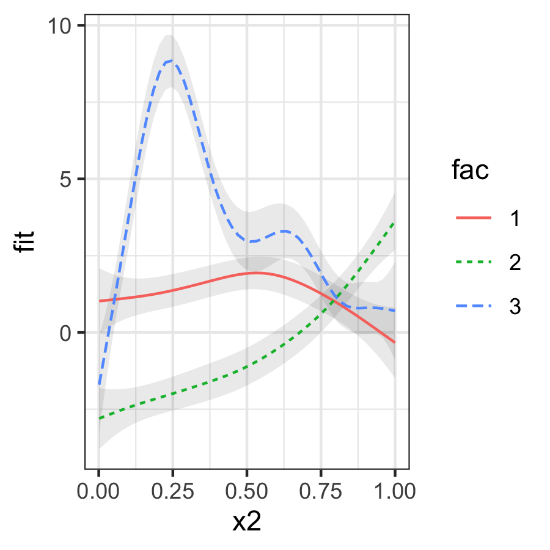

```r
model_p %>%
  ggplot(aes(x2, fit)) +
  geom_smooth_ci(fac)
```

## Surface smooths

Now let’s plot a model that has a tensor product interaction term (`ti()`).

```r
model_2 <- gam(
  y ~
    s(x2) +
    s(f1) +
    ti(x2, f1),
  data = data
)

summary(model_2)
```

```
#>
#> Family: gaussian
#> Link function: identity
#>
#> Formula:
#> y ~ s(x2) + s(f1) + ti(x2, f1)
#>
#> Parametric coefficients:
#>             Estimate Std. Error t value Pr(>|t|)
#> (Intercept)   1.4766     0.1527    9.67   <2e-16 ***
#> ---
#> Signif. codes:  0 '***' 0.001 '**' 0.01 '*' 0.05 '.' 0.1 ' ' 1
#>
#> Approximate significance of smooth terms:
#>             edf Ref.df     F p-value
#> s(x2)     1.477  1.871 1.005 0.36103
#> s(f1)     1.000  1.000 1.279 0.25870
#> ti(x2,f1) 1.000  1.000 7.421 0.00673 **
#> ---
#> Signif. codes:  0 '***' 0.001 '**' 0.01 '*' 0.05 '.' 0.1 ' ' 1
#>
#> R-sq.(adj) =  0.0662   Deviance explained = 7.43%
#> GCV = 9.3692  Scale est. = 9.2644    n = 400
```

Let’s get the prediction dataframe and produce a contour plot. We can adjust labels and aesthetics using the usual `ggplot2` methods.

```r
model_2_p <- predict_gam(model_2)
model_2_p
```

```
#> # A tibble: 2,500 × 4
#>         x2      f1    fit se.fit
#>      <dbl>   <dbl>  <dbl>  <dbl>
#>  1 0.00134 0.00125 -1.35   0.585
#>  2 0.0217  0.00125 -1.27   0.574
#>  3 0.0421  0.00125 -1.19   0.587
#>  4 0.0625  0.00125 -1.12   0.620
#>  5 0.0829  0.00125 -1.04   0.670
#>  6 0.103   0.00125 -0.962  0.729
#>  7 0.124   0.00125 -0.887  0.795
#>  8 0.144   0.00125 -0.813  0.864
#>  9 0.164   0.00125 -0.740  0.933
#> 10 0.185   0.00125 -0.668  1.00
#> # … with 2,490 more rows
```

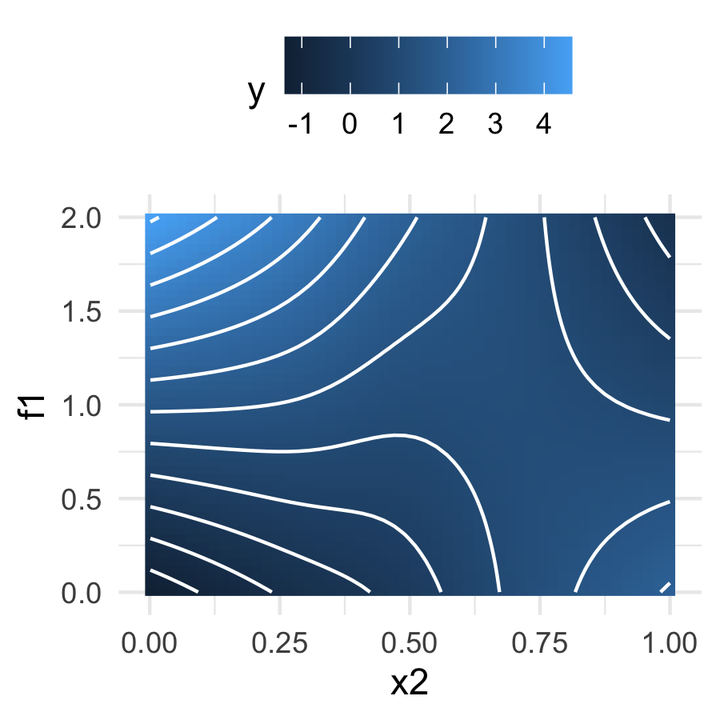

```r
model_2_p %>%
  ggplot(aes(x2, f1, z = fit)) +
  geom_raster(aes(fill = fit)) +
  geom_contour(colour = "white") +
  scale_fill_continuous(name = "y") +
  theme_minimal() +
  theme(legend.position = "top")
```

## Smooths at specified values of a continuous predictor

To plot the smooths across a few values of a continuous predictor, we can use the `values` argument in `predict_gam()`.

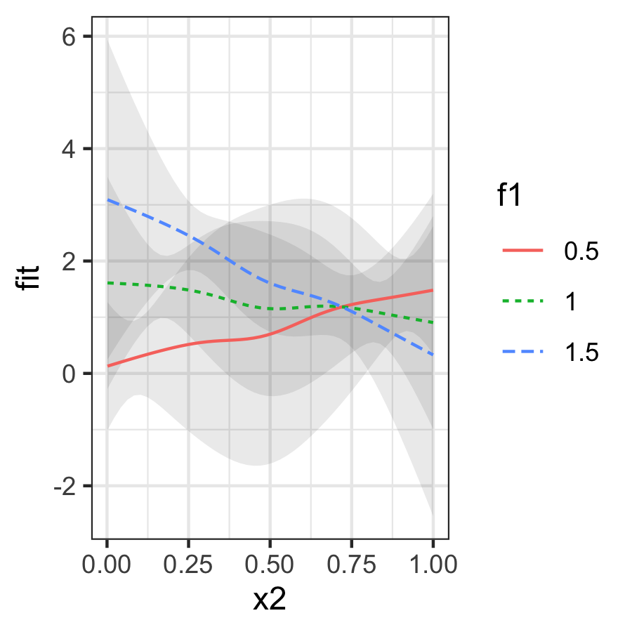

```r
predict_gam(model_2, values = list(f1 = c(0.5, 1, 1.5))) %>%
  ggplot(aes(x2, fit)) +
  geom_smooth_ci(f1)
```

## Exclude terms (like random effects)

It is possible to exclude terms when predicting values by means of the `exclude_terms` argument. This can be useful when there are random effects, like in the following model.

```r
data_re <- data %>%
  mutate(rand = rep(letters[1:4], each = 100), rand = as.factor(rand))

model_3 <- gam(
  y ~
    s(x2) +
    s(x2, rand, bs = "fs", m = 1),
  data = data_re
)
summary(model_3)
```

```
#>
#> Family: gaussian
#> Link function: identity
#>
#> Formula:
#> y ~ s(x2) + s(x2, rand, bs = "fs", m = 1)
#>
#> Parametric coefficients:
#>             Estimate Std. Error t value Pr(>|t|)
#> (Intercept)   1.5135     0.1839    8.23 2.85e-15 ***
#> ---
#> Signif. codes:  0 '***' 0.001 '**' 0.01 '*' 0.05 '.' 0.1 ' ' 1
#>
#> Approximate significance of smooth terms:
#>              edf Ref.df     F  p-value
#> s(x2)      4.222  5.143 4.473 0.000572 ***
#> s(x2,rand) 5.151 35.000 0.304 0.014734 *
#> ---
#> Signif. codes:  0 '***' 0.001 '**' 0.01 '*' 0.05 '.' 0.1 ' ' 1
#>
#> R-sq.(adj) =  0.0919   Deviance explained = 11.3%
#> GCV = 9.2497  Scale est. = 9.0098    n = 400
```

`exclude_terms` takes a character vector of term names, as they appear in the output of `summary()` (rather than as they are specified in the model formula). For example, to remove the term `s(x2, fac, bs = "fs", m = 1)`, `"s(x2,fac)"` should be used since this is how the summary output reports this term. The output still contains the excluded columns. The predicted values of the outcome variable are not affected by the value the excluded terms (the predicted values are repeated for each value of the excluded terms). In other words, the coefficients for the excluded terms are set to 0 when predicting. We can filter the predicted dataset to get unique predicted values by choosing any value or level of the excluded terms.\footnote{Alternatively, we can use `splice()`: `group_by(a) %>% splice(1)`. See `?splice`.}

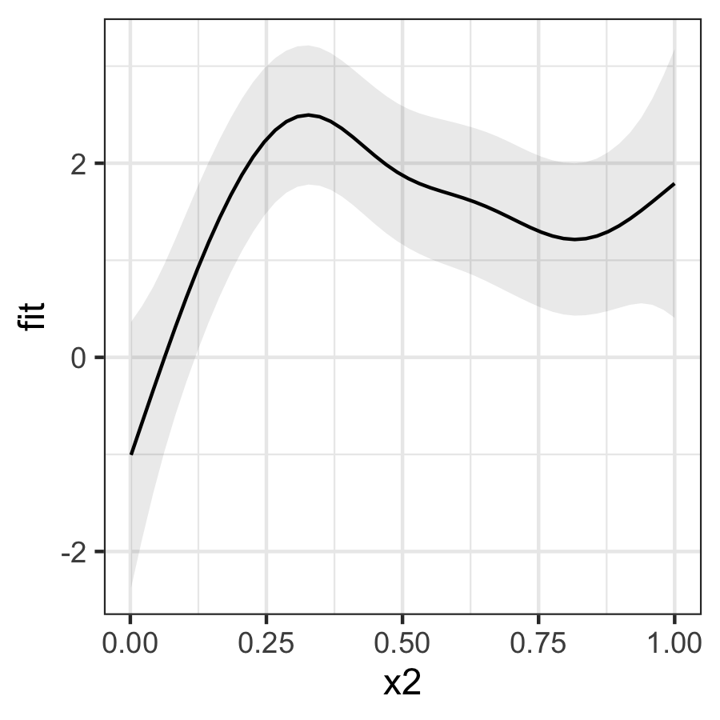

```r
predict_gam(model_3, exclude_terms = "s(x2,rand)") %>%
  filter(rand == "a") %>%
  ggplot(aes(x2, fit)) +
  geom_smooth_ci()
```

To speed up the calculation of the predictions when excluding terms, it is helpful to select a single value for the unnecessary terms using the `values` argument, rather than filtering with `filter()`. As with `filter()`, any value of the excluded variable can be used. If the value is `NULL`, the first value/level of the term is automatically selected (in the example below, `values = list(rand = NULL)` and `values = list(rand = "a")` would be equivalent).

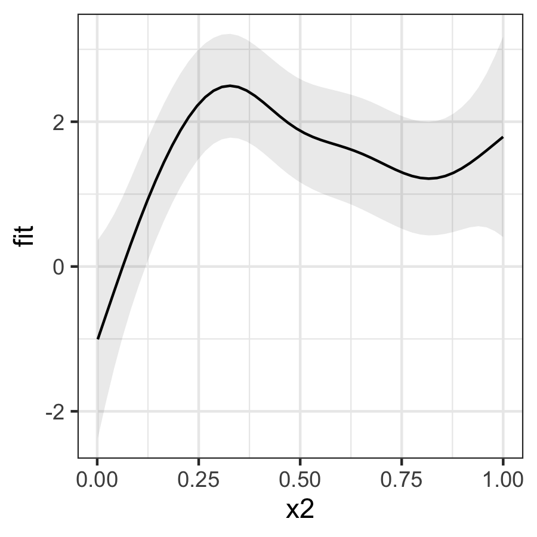

```r
predict_gam(model_3, exclude_terms = "s(x2,rand)", values = list(rand = NULL)) %>%
  ggplot(aes(x2, fit)) +
  geom_smooth_ci()
```

Of course, it is possible to plot the predicted values of random effects if we wish to do so. In the following example, the random effect `rand` is not excluded when predicting, and it is used to facet the plot.

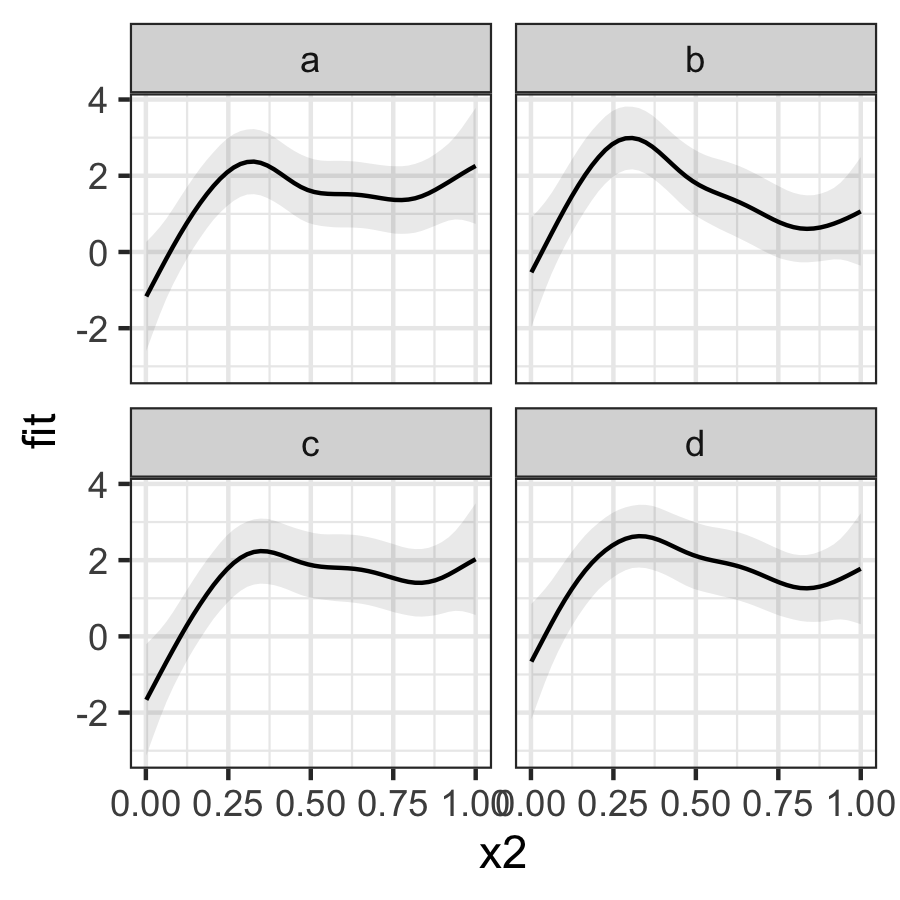

```r
predict_gam(model_3) %>%
  ggplot(aes(x2, fit)) +
  geom_smooth_ci() +
  facet_wrap(~rand)
```